# TidyTemplate

2023-02-07

# TidyTuesday

Join the R4DS Online Learning Community in the weekly #TidyTuesday event! Every week we post a raw dataset, a chart or article related to that dataset, and ask you to explore the data. While the dataset will be “tamed”, it will not always be tidy! As such you might need to apply various R for Data Science techniques to wrangle the data into a true tidy format. The goal of TidyTuesday is to apply your R skills, get feedback, explore other’s work, and connect with the greater #RStats community! As such we encourage everyone of all skills to participate!

# Load the weekly Data

Download the weekly data and make available in the `tt` object.

```r
tt <- tt_load("2023-02-07")
```

```
## --- Compiling #TidyTuesday Information for 2023-02-07 ----
```

```
## --- There are 2 files available ---
```

```
## --- Starting Download ---
```

```
## --- Download complete ---
```

# Readme

Take a look at the readme for the weekly data to get insight on the dataset. This includes a data dictionary, source, and a link to an article on the data.

```r
tt
```

# Glimpse Data

Take an initial look at the format of the data available.

```r
tt %>%
  map(glimpse)
```

```
## Rows: 45,088
## Columns: 8
## $ stock_symbol <chr> "AAPL", "AAPL", "AAPL", "AAPL", "AAPL", "AAPL", "AAPL", "…
## $ date         <date> 2010-01-04, 2010-01-05, 2010-01-06, 2010-01-07, 2010-01-…
## $ open         <dbl> 7.622500, 7.664286, 7.656429, 7.562500, 7.510714, 7.60000…
## $ high         <dbl> 7.660714, 7.699643, 7.686786, 7.571429, 7.571429, 7.60714…
## $ low          <dbl> 7.585000, 7.616071, 7.526786, 7.466071, 7.466429, 7.44464…
## $ close        <dbl> 7.643214, 7.656429, 7.534643, 7.520714, 7.570714, 7.50392…
## $ adj_close    <dbl> 6.515213, 6.526476, 6.422664, 6.410790, 6.453412, 6.39648…
## $ volume       <dbl> 493729600, 601904800, 552160000, 477131200, 447610800, 46…
## Rows: 14
## Columns: 2
## $ stock_symbol <chr> "AAPL", "ADBE", "AMZN", "CRM", "CSCO", "GOOGL", "IBM", "I…
## $ company      <chr> "Apple Inc.", "Adobe Inc.", "Amazon.com, Inc.", "Salesfor…
```

```
## $big_tech_stock_prices
## # A tibble: 45,088 × 8
##    stock_symbol date        open  high   low close adj_close    volume
##    <chr>        <date>     <dbl> <dbl> <dbl> <dbl>     <dbl>     <dbl>
##  1 AAPL         2010-01-04  7.62  7.66  7.58  7.64      6.52 493729600
##  2 AAPL         2010-01-05  7.66  7.70  7.62  7.66      6.53 601904800
##  3 AAPL         2010-01-06  7.66  7.69  7.53  7.53      6.42 552160000
##  4 AAPL         2010-01-07  7.56  7.57  7.47  7.52      6.41 477131200
##  5 AAPL         2010-01-08  7.51  7.57  7.47  7.57      6.45 447610800
##  6 AAPL         2010-01-11  7.6   7.61  7.44  7.50      6.40 462229600
##  7 AAPL         2010-01-12  7.47  7.49  7.37  7.42      6.32 594459600
##  8 AAPL         2010-01-13  7.42  7.53  7.29  7.52      6.41 605892000
##  9 AAPL         2010-01-14  7.50  7.52  7.46  7.48      6.38 432894000
## 10 AAPL         2010-01-15  7.53  7.56  7.35  7.35      6.27 594067600
## # … with 45,078 more rows
```

[output cut: 19 more lines]

# Wrangle

Explore the data and process it into a nice format for plotting! Access each dataset by name by using a dollarsign after the `tt` object and then the name of the data set.

```r
library(quantmod)
# stocks <- tt$big_tech_companies %>%
#   inner_join(tt$big_tech_stock_prices, by = "stock_symbol") %>%
#   mutate(company_short = str_remove(str_remove(str_remove(company, " Corporation"), " Inc."), ","),
#          company_short = case_when(
#            company_short == "International Business Machines" ~ "IBM",
#            company_short == "Cisco Systems" ~ "Cisco",
#            company_short == "Meta Platforms" ~ "Meta",
#            TRUE ~ company_short
#          ))

stock_symbols <- tt$big_tech_companies %>%
  distinct(stock_symbol) %>%
  pull(stock_symbol)

getSymbols(stock_symbols, src = 'yahoo')
```

```
## pausing 1 second between requests for more than 5 symbols
```

[output not shown]

```
##  [1] "AAPL"  "ADBE"  "AMZN"  "CRM"   "CSCO"  "GOOGL" "IBM"   "INTC"  "META"
## [10] "MSFT"  "NFLX"  "NVDA"  "ORCL"  "TSLA"
```

```r
xts_to_df <- function(df){
  name = deparse(substitute(df))

  output <- df %>%
    fortify.zoo() %>%
    as_tibble() %>%
    mutate(stock_symbol = name) %>%
    select(stock_symbol,
           date = 1,
           open = 2,
           high = 3,
           low = 4,
           close = 5,
           adj_close = 7,
           volume = 6) %>%
    filter(date >= ymd("2012-05-18"))

  return(output)
}

stocks <- xts_to_df(AAPL) %>%
  bind_rows(xts_to_df(ADBE)) %>%
  bind_rows(xts_to_df(AMZN)) %>%
  bind_rows(xts_to_df(CRM)) %>%
  bind_rows(xts_to_df(CSCO)) %>%
  bind_rows(xts_to_df(GOOGL)) %>%
  bind_rows(xts_to_df(IBM)) %>%
  bind_rows(xts_to_df(INTC)) %>%
  bind_rows(xts_to_df(META)) %>%
  bind_rows(xts_to_df(MSFT)) %>%
  bind_rows(xts_to_df(NFLX)) %>%
  bind_rows(xts_to_df(NVDA)) %>%
  bind_rows(xts_to_df(ORCL)) %>%
  bind_rows(xts_to_df(TSLA)) %>%
  inner_join(tt$big_tech_companies, by = "stock_symbol") %>%
  mutate(company_short = str_remove(str_remove(str_remove(company, " Corporation"), " Inc."), ","),
         company_short = case_when(
           company_short == "International Business Machines" ~ "IBM",
           company_short == "Cisco Systems" ~ "Cisco",
           company_short == "Meta Platforms" ~ "Meta",
           TRUE ~ company_short
         ))
```

# Visualize

Using your processed dataset, create your unique visualization.

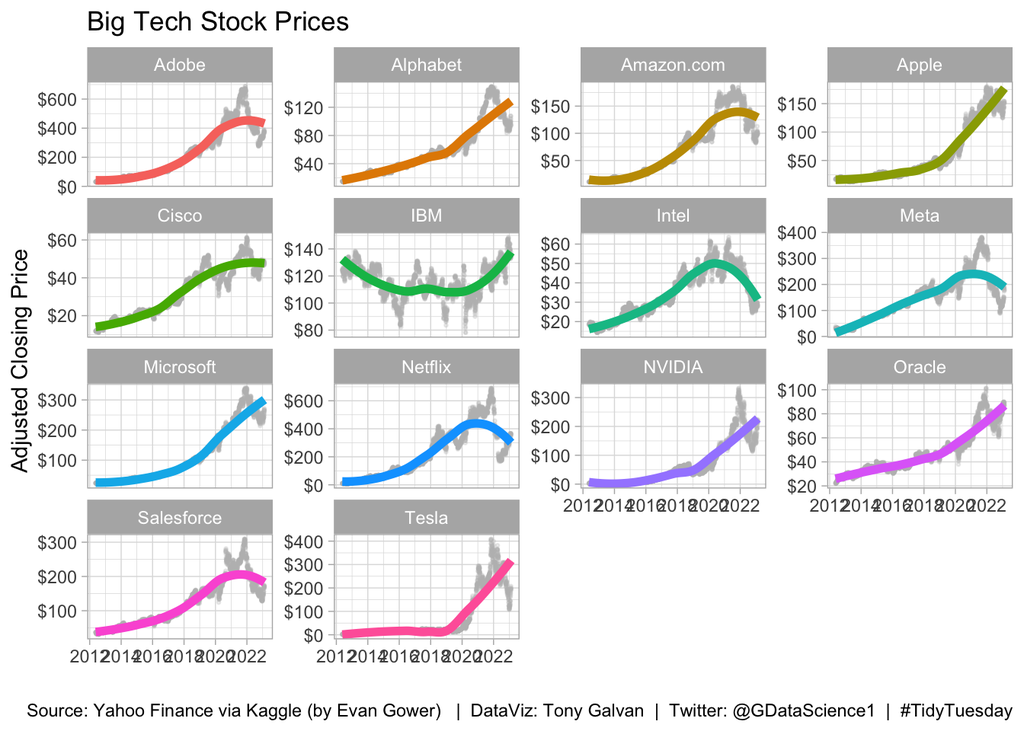

```r
stocks %>%
  ggplot(aes(date, adj_close)) +
  geom_point(color = "gray", alpha = 0.25, size = 0.5) +
  geom_smooth(aes(color = company_short), method = "loess", se = FALSE, lty = 1, size = 2) +
  facet_wrap(~company_short, scales = "free_y") +
  scale_y_continuous(labels = dollar_format()) +
  theme(legend.position = "none") +
  labs(x = "",
       y = "Adjusted Closing Price",
       title = "Big Tech Stock Prices",
       caption = tt_caption)
```

```r
library(reactable)
library(reactablefmtr)
stocks_df <- stocks %>%
  group_by(stock_symbol) %>%
  summarize(first_adj_close = dplyr::first(adj_close),
            last_adj_close = dplyr::last(adj_close)) %>%
  ungroup() %>%
  inner_join(stocks %>% distinct(stock_symbol, company_short), by = "stock_symbol") %>%
  mutate(pct_change = (last_adj_close - first_adj_close) / first_adj_close,
         logo = paste0("https://raw.githubusercontent.com/tashapiro/TidyTuesday/master/2023/W6/logos/",stock_symbol,".png")) %>%
  select(logo, company_short, stock_symbol, first_adj_close, last_adj_close, pct_change) %>%
  arrange(desc(pct_change))

stocks_table <- stocks_df %>%
  reactable(defaultPageSize = 14,
            theme = fivethirtyeight(),
            columns = list(
              logo = colDef(
                name = "",
                maxWidth = 70,
                align = "center",
                cell = embed_img(height = "25", width = "25")
    ),
              company_short = colDef(name = "COMPANY"),
              stock_symbol = colDef(name = "STOCK SYMBOL"),
              first_adj_close = colDef(name = "ADJUSTED CLOSE: 5/18/2012",
                                       format = colFormat(prefix = "$", separators = TRUE, digits = 2)),
              last_adj_close = colDef(name = "ADJUSTED CLOSE: 2/7/2023",
                                       format = colFormat(prefix = "$", separators = TRUE, digits = 2)),
              pct_change = colDef(name = "% CHANGE",
                                  format = colFormat(percent = TRUE, digits = 0),
                                  style = color_scales(stocks_df, colors = viridis::viridis(5)))
            ))  %>%
  add_title("Big Tech Stock Prices") %>%
  add_subtitle("How have their stock prices changed since Meta went public on 5/18/2012?") %>%
  add_source(tt_caption)

stocks_table
```

# Big Tech Stock Prices

## How have their stock prices changed since Meta went public on 5/18/2012?

|  | COMPANY | STOCK SYMBOL | ADJUSTED CLOSE: 5/18/2012 | ADJUSTED CLOSE: 2/7/2023 | % CHANGE |
| --- | --- | --- | --- | --- | --- |
| https://raw.githubusercontent.com/tashapiro/TidyTuesday/master/2023/W6/logos/TSLA.png | Tesla | TSLA | 1.837333 | 194.639999 | 104.936158007286 |
| https://raw.githubusercontent.com/tashapiro/TidyTuesday/master/2023/W6/logos/NVDA.png | NVIDIA | NVDA | 2.771612 | 217.880005 | 77.6112937164365 |
| https://raw.githubusercontent.com/tashapiro/TidyTuesday/master/2023/W6/logos/NFLX.png | Netflix | NFLX | 9.994286 | 358.570007 | 34.8775011041309 |
| https://raw.githubusercontent.com/tashapiro/TidyTuesday/master/2023/W6/logos/ADBE.png | Adobe | ADBE | 31.309999 | 375 | 10.9770045345578 |
| https://raw.githubusercontent.com/tashapiro/TidyTuesday/master/2023/W6/logos/MSFT.png | Microsoft | MSFT | 23.780977 | 271.320007 | 10.4091194402989 |
| https://raw.githubusercontent.com/tashapiro/TidyTuesday/master/2023/W6/logos/AAPL.png | Apple | AAPL | 16.122002 | 153.850006 | 8.54285987559113 |
| https://raw.githubusercontent.com/tashapiro/TidyTuesday/master/2023/W6/logos/AMZN.png | Amazon.com | AMZN | 10.6925 | 99.540001 | 8.30932906242693 |
| https://raw.githubusercontent.com/tashapiro/TidyTuesday/master/2023/W6/logos/GOOGL.png | Alphabet | GOOGL | 15.025025 | 94.610001 | 5.29682819163362 |
| https://raw.githubusercontent.com/tashapiro/TidyTuesday/master/2023/W6/logos/CRM.png | Salesforce | CRM | 36.395 | 171.080002 | 3.70064574804231 |
| https://raw.githubusercontent.com/tashapiro/TidyTuesday/master/2023/W6/logos/META.png | Meta | META | 38.23 | 179.429993 | 3.69343429244049 |

[output cut: 4 more lines]

Source: Yahoo Finance via Kaggle (by Evan Gower) | DataViz: Tony Galvan | Twitter: @GDataScience1 | #TidyTuesday

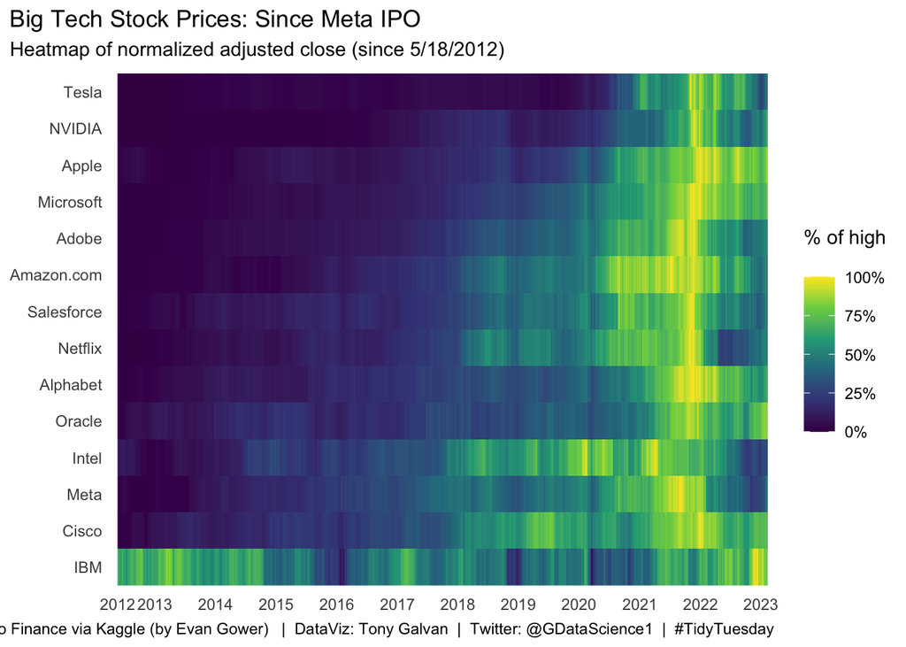

```r
library(bdscale)

stocks %>%
  group_by(company_short) %>%
  mutate(period_high = max(adj_close),
         period_low = min(adj_close)) %>%
  ungroup() %>%
  mutate(normalized_value = (adj_close - period_low) / (period_high - period_low),
         company_short = fct_reorder(company_short, -normalized_value)) %>%
  ggplot(aes(date, company_short, fill = normalized_value)) +
  geom_raster() +
  scale_fill_viridis_c(labels = percent_format()) +
  scale_x_bd(business.dates = unique(stocks$date),
             max.major.breaks = 12,
             labels = date_format("%Y"),
             expand = c(0.01, 0)) +
  theme(panel.grid = element_blank(),
        panel.border = element_blank(),
        axis.ticks = element_blank(),
        axis.title = element_blank(),
        plot.title.position = "plot") +
  labs(fill = "% of high\n ",
       title = "Big Tech Stock Prices: Since Meta IPO",
       subtitle = "Heatmap of normalized adjusted close (since 5/18/2012)",
       caption = tt_caption)
```

# Save Image

Save your image for sharing. Be sure to use the `#TidyTuesday` hashtag in your post on twitter!

```r
# This will save your most recent plot
ggsave(
  filename = "2023_02_07_tidy_tuesday_stocks.png",
  device = "png")
save_reactable(stocks_table, "2023_02_07_tidy_tuesday_stocks2.png")
```

```
## image saved to /Users/anthonygalvan/Documents/GitHub/tidytuesday/2023_02_07_tidy_tuesday_stocks2.png
```